# Winter Institute in Data Science and Big Data

Introducing Python

Le Bao

Massive Data Institute, Georgetown University

January 5, 2024

## Plan

- Python
  - Basics
  - Data structures
  - `NumPy` and `Pandas`
- Comparative computing
  - Python, R, Shell
  - Polyglot programming and computing tools
  - Computing environment
- Containers and cloud computing
  - Operating systems and system dependencies
  - Docker
  - Cloud computing with Code Ocean

## What is Python?

*“Python is a high-level programming language, and its core design philosophy is all about code readability and a syntax which allows programmers to express concepts in a few lines of code.”*

- Open-source
- General-purpose
- Interpreted
- Object-oriented
- Currently, one of the most popular programming languages

## The Zen of Python

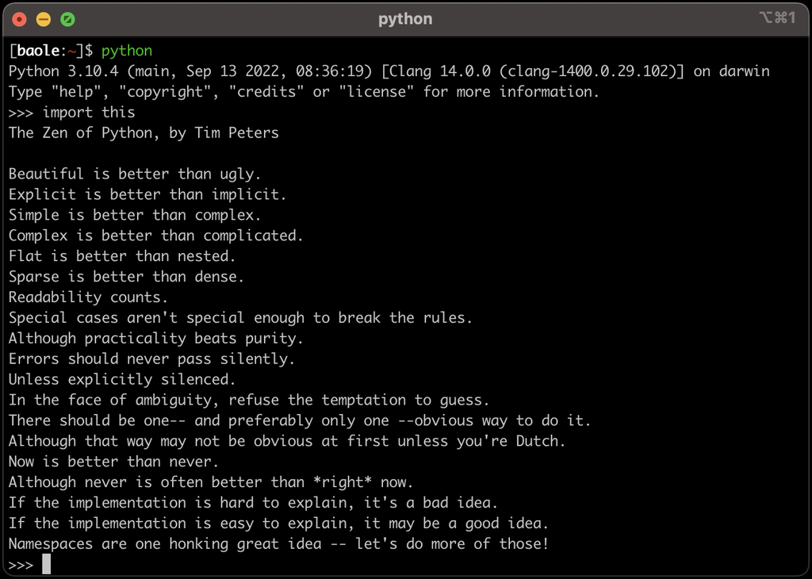

## Python Ecosystem

- Web data & development: `BeautifulSoup`, `Selenium`, `Scrapy`, `Django`, `Flask`
- Data analysis and modeling: `Pandas`, `NumPy`, `Matplotlib`, `SciPy`
- Machine learning: `Scikit-Learn`, `TensorFlow`, `Keras`, `PyTorch`, `LightGBM`
- Computer vision: `OpenCV`, `Pillow`
- GUI app and game dev: `TkinterA`, `PygameA`, `PyOpenGL`
- Code presenting and reproducibity: `JupyterLab`
- Internet of Things: Raspberry Pi + python

## Setup

- Anaconda distribution: https://www.anaconda.com/products/distribution
  - Everything you need is *out of the box*
- IDE:
  - Spyder (IDE/editor) - like RStudio
  - Visual Studio Code
  - …
- Notebook
  - Jupyter Notebook
  - Google Colab (https://colab.research.google.com/)

## Data Types

- Integer `<int>`
- Float `<float>`
- String `<str>`
- Boolean `<bool>`

```python
type(5)
```

```
int
```

```python
type('hello')
```

```
str
```

```python
type(3.1415926)
```

```
float
```

## Variables

```python
x = 3.5
y = 2.7
z = x + y
z
```

```
6.2
```

```python
x = 'hello'
y = 'world'
z = x + ' ' + y
z
```

```
'hello world'
```

## Operators

- `+` plus
- `-` minus
- `*` multiply
- `/` divide
- `==` equal (`<`, `>`, `<=`, `>=`)
- `and`
- `or`
- `not`

## Operators

```python
x = 3.5
y = 'python'
x == 3.6
```

```
False
```

```python
type(y) == str
```

```
True
```

```python
(x == 3.6) and (type(y) == str)
```

```
False
```

```python
(x == 3.6) or (type(y) == str)
```

```
True
```

## Conditions

- **if/else**:
  - if/else statement executes a block of code if a specified condition is true. If condition is not met, another block of code can be executed.

```python
num = 3.14

if (num >= 10):
    print('The number is larger than 10')
elif (num < 0):
    print('The number is negative')
elif (num == 0):
    print('The number equals zero')
else:
    print('The number is smaller than 10')
```

```
The number is smaller than 10
```

## Loops

- For loops

```python
for i in range(5):
  print(i)
```

```
0
1
2
3
4
```

```python
range(5)
```

```
range(0, 5)
```

```python
for i in range(1,5):
  print(i)
```

```
1
2
3
4
```

## Loops

- While loops

```python
num = 10

while(num <= 20):
    print('The number', num, 'is smaller than 20')
    num+=2
```

```
The number 10 is smaller than 20
The number 12 is smaller than 20
The number 14 is smaller than 20
The number 16 is smaller than 20
The number 18 is smaller than 20
The number 20 is smaller than 20
```

## Loops

- Enumerate in Loops

```python
for i, value in enumerate(['a', 'b', 'c', 'd', 'e']):
    print(i, value)
```

```
0 a
1 b
2 c
3 d
4 e
```

## Functions

```python
def sum_two_number(a,b):
  res = a + b
  return res

sum_two_number(5,7)
```

```
12
```

```python
def even_or_odd(x):
  if x%2==0:
    return 'Even'
  else:
    return 'Odd'
```

```python
even_or_odd(4)
```

```
'Even'
```

```python
even_or_odd(201)
```

```
'Odd'
```

## Exercise: Function

- Write a function to compare two values and return the larger one

```python
def find_larger_number(a,b):
  if a >= b: res = a
  if a < b: res = b
  return res
```

```python
find_larger_number(5,7)
```

```
7
```

## Data Structures

- Tuples, Lists, Sets, Dictionaries
- “Containers” that organize and group data according to type.
- Each is unique in its own way

## Tuple

- A tuple is an (**immutable**) ordered list of values

```python
t1 = () # Empty tuple
t2 = (1,2,3)
t3 = (1, "AU", 3.1, False, 1)
t3
```

```
(1, 'AU', 3.1, False, 1)
```

- Methods for tuples

```python
t3.count(1)
```

```
2
```

```python
t3.index("AU")
```

```
1
```

```python
list(t3)
```

```
[1, 'AU', 3.1, False, 1]
```

## List

- A list is the Python equivalent of an array, but is mutable and can contain elements of different types

```python
l1 = []
l1 = list()
l2 = [1,"AU", True]
l2
```

```
[1, 'AU', True]
```

- Indexing/Slicing

```python
nums = list(range(10))
print(nums)
```

```
[0, 1, 2, 3, 4, 5, 6, 7, 8, 9]
```

```python
nums[5:6]
```

```
[5]
```

## List

- List methods

```python
progs = ["Python", "R", "Julia"]
print(progs)
```

```
['Python', 'R', 'Julia']
```

```python
progs.append("C++")
print(progs)
```

```
['Python', 'R', 'Julia', 'C++']
```

```python
progs.remove("C++")
progs.insert(1, "C++")
print(progs)
```

```
['Python', 'C++', 'R', 'Julia']
```

```python
nums = [1,3,2,5,4]
nums.sort()
print(nums)
```

```
[1, 2, 3, 4, 5]
```

## List

- Use list with loops

```python
for p in progs:
  print(p)
```

```
Python
C++
R
Julia
```

```python
for i in range(2,len(progs)):
  print(progs[i])
```

```
R
Julia
```

```python
len(progs)
```

```
4
```

## Sets

- A set is an **unordered** collection with **no duplicate elements**.

```python
progs = {"python", "R", "C++", "R", "Julia"}
print(progs)
```

```
{'python', 'C++', 'R', 'Julia'}
```

```python
nums = [1, 2, 3, 4, 4]
unique_nums = set(nums)
print(unique_nums)
```

```
{1, 2, 3, 4}
```

```python
print(list(unique_nums))
```

```
[1, 2, 3, 4]
```

## Dictionary

- A dictionary stores (key, value) pairs to map data

```python
prog_dict = {1:"C++", 3:"R", 2:"python", 4:"Julia"}
print(prog_dict)
```

```
{1: 'C++', 3: 'R', 2: 'python', 4: 'Julia'}
```

```python
prog_dict[2]
```

```
'python'
```

```python
tokyo = {'city':"Tokyo", 'country':"Japan", 'pop': 37468000}
tokyo['country']
```

```
'Japan'
```

```python
print(tokyo.keys())
```

```
dict_keys(['city', 'country', 'pop'])
```

## Dictionary

- Dictionary, list, and loop

```python
delhi = {'city':"Delhi", 'country':"India", 'pop': 28514000}
shanghai = {'city':"Shanghai", 'country':"China", 'pop': 25582000}
megacities= [tokyo,delhi,shanghai]
print(megacities)
```

```
[{'city': 'Tokyo', 'country': 'Japan', 'pop': 37468000}, {'city': 'Delhi', 'country': 'India', 'pop': 28514000}, {'city': 'Shanghai', 'country': 'China', 'pop': 25582000}]
```

```python
for m in megacities:
  print(m['city'] + ", " + m['country'], "has a population of", m['pop'])
```

```
Tokyo, Japan has a population of 37468000
Delhi, India has a population of 28514000
Shanghai, China has a population of 25582000
```

## Some Feature

- Working with multiple objects

```python
a, b = 5, 10
print(a)
```

```
5
```

- Unpacking

```python
point = (3, 4)
x, y = point
print(y)
```

```
4
```

- Extended unpacking

```python
first, *middle, last = [1, 2, 3, 4, 5]
print(middle)
```

```
[2, 3, 4]
```

## Exercise: List, Function, and Loop

- Create a list of numbers and find all the prime numbers in it
- Hint:
  - You may need to use list, function, and/or loop.
  - You can use for loop to test all the divisors.

## Exercise: List, Function, and Loop

```python
def is_prime(x):
  for i in range(2,x):
    if x%i==0:return False
  return True

def find_prime(a,b):
  prime_list = []
  for num in range(a,b+1):
    if is_prime(num): prime_list.append(num)
  return prime_list
```

```python
find_prime(1,10)
```

```
[1, 2, 3, 5, 7]
```

```python
len(find_prime(1,100))
```

```
26
```

## Python for Data Science: `NumPy` and `Pandas`

- `NumPy`: Numeric computing library
- `Pandas`: Data structures and manipulation tools
- Install python libraries (shell session)

```python
pip install numpy pandas
```

- Import python libraries/modules

```python
import numpy
import numpy as np
import pandas
import pandas as pd
from pandas import Series, DataFrame
```

## `NumPy` Basics

- An efficient multidimensional array providing fast array-oriented arithmetic operations and flexible broadcasting capabilities.
- Mathematical functions for fast operations on entire arrays of data without having to write loops.
- Tools for reading/writing array data, linear algebra, random number generation, and Fourier transform capabilities, A C API for connecting NumPy with libraries written in `C`, `C++`, or `FORTRAN`, etc.

## `NumPy` Array

```python
arr1 = np.array([1, 2, 3, 4, 5])
print(arr1)
```

```
[1 2 3 4 5]
```

```python
arr1 ** 2
```

```
array([ 1,  4,  9, 16, 25])
```

```python
arr2 = np.arange(1000000)
print(arr2)
```

```
[     0      1      2 ... 999997 999998 999999]
```

```python
arr3 =np.array([[1.5, -0.1, 3], [0, -3, 6.5]])
print(arr3)
```

```
[[ 1.5 -0.1  3. ]
 [ 0.  -3.   6.5]]
```

```python
arr3.shape
```

```
(2, 3)
```

## `NumPy` Array

```python
arr1.mean()
```

```
3.0
```

```python
arr1.sum()
```

```
15
```

```python
arr4 = np.array([6, 0, 0, 3, 2, 5, 6])
np.unique(arr4)
```

```
array([0, 2, 3, 5, 6])
```

```python
np.sort(arr4)
```

```
array([0, 0, 2, 3, 5, 6, 6])
```

## `Pandas` Basics

- Designed for working with tabular or heterogeneous data
- Built on top of `NumPy`, offering a more data science oriented interface
- Data frame, data wrangling, reading/writing tabular data, etc.

## `Pandas` Data Frame

```python
states = {"state": ["Ohio", "Ohio", "Ohio", "Nevada", "Nevada", "Nevada"],
        "year": [2000, 2001, 2002, 2001, 2002, 2003],
        "pop": [1.5, 1.7, 3.6, 2.4, 2.9, 3.2]}
states_df = pd.DataFrame(states)
states_df
```

|  | state | year | pop |
| --- | --- | --- | --- |
| 0 | Ohio | 2000 | 1.5 |
| 1 | Ohio | 2001 | 1.7 |
| 2 | Ohio | 2002 | 3.6 |
| 3 | Nevada | 2001 | 2.4 |
| 4 | Nevada | 2002 | 2.9 |
| 5 | Nevada | 2003 | 3.2 |

## `Pandas` Data Frame

```python
states_df['state']
```

```
0      Ohio
1      Ohio
2      Ohio
3    Nevada
4    Nevada
5    Nevada
Name: state, dtype: object
```

```python
states_df.year
```

```
0    2000
1    2001
2    2002
3    2001
4    2002
5    2003
Name: year, dtype: int64
```

```python
states_df['region'] = ['East', 'East', 'East', 'West', 'West', 'West']
```

## `Pandas` Series

```python
ser = pd.Series([4, 7, -5, 3])
print(ser)
```

```
0    4
1    7
2   -5
3    3
dtype: int64
```

```python
debt_val = pd.Series([-1.2, -1.5, -1.7], index=[2, 4, 5])
states_df["debt"] = debt_val
states_df
```

|  | state | year | pop | region | debt |
| --- | --- | --- | --- | --- | --- |
| 0 | Ohio | 2000 | 1.5 | East | NaN |
| 1 | Ohio | 2001 | 1.7 | East | NaN |
| 2 | Ohio | 2002 | 3.6 | East | -1.2 |
| 3 | Nevada | 2001 | 2.4 | West | NaN |
| 4 | Nevada | 2002 | 2.9 | West | -1.5 |
| 5 | Nevada | 2003 | 3.2 | West | -1.7 |

## `Pandas` Data Frame

```python
states_df.head()
states_df.tail(3)
```

|  | state | year | pop | region | debt |
| --- | --- | --- | --- | --- | --- |
| 3 | Nevada | 2001 | 2.4 | West | NaN |
| 4 | Nevada | 2002 | 2.9 | West | -1.5 |
| 5 | Nevada | 2003 | 3.2 | West | -1.7 |

```python
states_df.loc[1]
states_df.iloc[2:4]
```

|  | state | year | pop | region | debt |
| --- | --- | --- | --- | --- | --- |
| 2 | Ohio | 2002 | 3.6 | East | -1.2 |
| 3 | Nevada | 2001 | 2.4 | West | NaN |

## `Pandas` Data Frame

```python
avg_pop = states_df.groupby('state')['pop'].mean()
avg_pop
```

```
state
Nevada    2.833333
Ohio      2.266667
Name: pop, dtype: float64
```

## `Pandas` Data Frame

- Writing data

```python
states_df.to_csv('states.csv', index=False)
```

- Reading data

```python
states_df2 = pd.read_csv('states.csv')
states_df2
```

|  | state | year | pop | region | debt |
| --- | --- | --- | --- | --- | --- |
| 0 | Ohio | 2000 | 1.5 | East | NaN |
| 1 | Ohio | 2001 | 1.7 | East | NaN |
| 2 | Ohio | 2002 | 3.6 | East | -1.2 |
| 3 | Nevada | 2001 | 2.4 | West | NaN |
| 4 | Nevada | 2002 | 2.9 | West | -1.5 |
| 5 | Nevada | 2003 | 3.2 | West | -1.7 |

## Web Data and API

- ChatGPT API

```python
!pip install openai pandas
import openai

response = client.chat.completions.create(
  model="gpt-3.5-turbo",
  messages=[
    {"role": "system", "content": "You are a helpful assistant."},
    {"role": "user", "content": "Who won the world series in 2020?"},
    {"role": "assistant", "content": "The Los Angeles Dodgers won the World Series in 2020."},
    {"role": "user", "content": "Where was it played?"}
  ]
)
```

## Exercise: API

- Use ChatGPT API to create another column for the states data
  - Load `openai` library and setup the api key

```python
import openai
import re
openai.api_key = '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'
```

## Exercise: API

- Use ChatGPT API to create another column for the states data
  - Load `openai` library and setup the api key
  - Create a function to interact with ChatGPT

```python
def gptStateIncome(state, year):
    response = openai.chat.completions.create(
        model="gpt-3.5-turbo",
        messages=[
            {"role": "system", "content": "You are an assistant knowledgeable in census statistics."},
            {"role": "user", "content": f"What was the median household income in {state} in {year}?"},
        ]
    )
    content = response.choices[0].message.content.strip()
    income = re.search(r'\$\d+(?:,\d+)?', content)
```

```python
gptStateIncome("Nevada", 2001)
```

## Exercise: ChatGPT API

- Use ChatGPT API to create another column for the states data
  - Load `openai` library and setup the api key
  - Create a function to interact with ChatGPT
  - Use a for loop (or `apply` function) to fetch the data

```python
median_income = []

for i in range(len(states_df)):
    sel = states_df.iloc[i]
    x = gptStateIncome(sel['state'], sel['year'])
    median_income.append(x)
```

## Exercise: ChatGPT API

- Use ChatGPT API to create another column for the states data
  - Load `openai` library and setup the api key
  - Create a function to interact with ChatGPT
  - Use a for loop (or `apply` function) to fetch the data
  - Create a new column in the state data frame
  - Calculate the average median household income
  - …
- Example code: https://bit.ly/audatapy24

Le Bao · AU Winter Institute · https://baole.io/